# Solutions

### Mass histograms

Below is an example solution for stars with $M < M_{\odot}$. First I created a new dataframe with just the low mass stars. I then created the histograms and the caption.

```
low_mass_df = planet_df.where(planet_df['star_mass'] <=1.0).dropna()
```

```
low_mass_df
```

|  | name | orbital_period | semi_major_axis | detection_type | star_mass |
| --- | --- | --- | --- | --- | --- |
| 3 | 14 Her b | 1773.4000 | 2.770000 | Radial Velocity | 0.900 |
| 6 | 1SWASP J1407 b | 3725.0000 | 3.900000 | Primary Transit | 0.900 |
| 7 | 24 Boo b | 30.3506 | 0.190000 | Radial Velocity | 0.990 |
| 13 | 42 Dra b | 479.1000 | 1.190000 | Radial Velocity | 0.980 |
| 24 | 61 Vir b | 4.2150 | 0.050201 | Radial Velocity | 0.950 |
| ... | ... | ... | ... | ... | ... |
| 3798 | eps Ind A b | 16509.0000 | 11.550000 | Radial Velocity | 0.762 |
| 3823 | tau Cet e | 162.8700 | 0.538000 | Radial Velocity | 0.783 |
| 3824 | tau Cet f | 636.1300 | 1.334000 | Radial Velocity | 0.783 |
| 3825 | tau Cet g | 20.0000 | 0.133000 | Radial Velocity | 0.783 |
| 3826 | tau Cet h | 49.4100 | 0.243000 | Radial Velocity | 0.783 |

1074 rows × 5 columns

```
fig = plt.figure(figsize=(10,6))
ax = fig.add_subplot(1,1,1)
ax.hist(low_mass_df['star_mass'].where(low_mass_df['detection_type']=='Primary Transit'), bins=15, label='Primary Transit', alpha=0.6, color='DeepPink', edgecolor='DeepPink')
ax.hist(low_mass_df['star_mass'].where(low_mass_df['detection_type']=='Radial Velocity'), bins=15, label='Radial Velocity', alpha=0.7, color='DodgerBlue', edgecolor='DodgerBlue')
ax.set_xlabel('Host star mass ($M_\odot$)')
ax.set_ylabel('Count')
ax.legend()
ax.set_title('Number of exoplanets detected using transit and radial velocity\n  techniques for host star masses below 1 $M_{\odot}$')
plt.show()
```

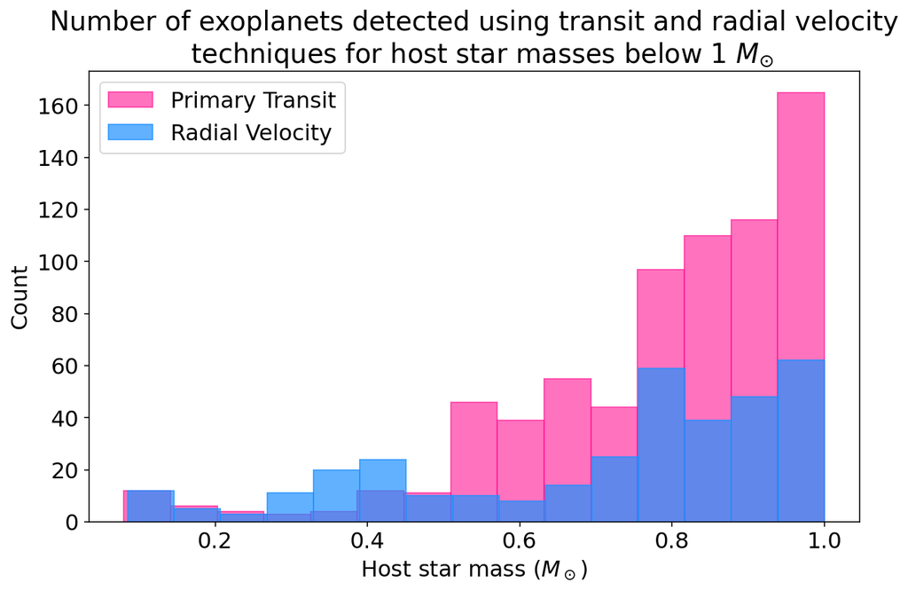

### Clean your data

```
kepler_df = planet_df.where((planet_df['orbital_period'] <= 10000) & (planet_df['star_mass'] > 0.7)).dropna()
```

```
kepler_df
```

|  | name | orbital_period | semi_major_axis | detection_type | star_mass |
| --- | --- | --- | --- | --- | --- |
| 0 | 11 Com b | 326.03000 | 1.2900 | Radial Velocity | 2.70 |
| 1 | 11 UMi b | 516.22000 | 1.5400 | Radial Velocity | 1.80 |
| 2 | 14 And b | 185.84000 | 0.8300 | Radial Velocity | 2.20 |
| 3 | 14 Her b | 1773.40000 | 2.7700 | Radial Velocity | 0.90 |
| 4 | 16 Cyg B b | 799.50000 | 1.6800 | Radial Velocity | 1.01 |
| ... | ... | ... | ... | ... | ... |
| 3827 | tau Gem b | 305.50000 | 1.1700 | Radial Velocity | 2.30 |
| 3828 | ups And b | 4.61711 | 0.0590 | Radial Velocity | 1.27 |
| 3829 | ups And c | 240.93700 | 0.8610 | Radial Velocity | 1.27 |
| 3830 | ups And d | 1281.43900 | 2.5500 | Radial Velocity | 1.27 |
| 3831 | ups And e | 3848.86000 | 5.2456 | Radial Velocity | 1.27 |

1719 rows × 5 columns

Check that we've actually got what we want by looking at the data:

```
kepler_df['orbital_period'].max()
```

```
9018.0
```

```
kepler_df['star_mass'].min()
```

```
0.707
```

```
kepler_df['orbital_period'].hist()
```

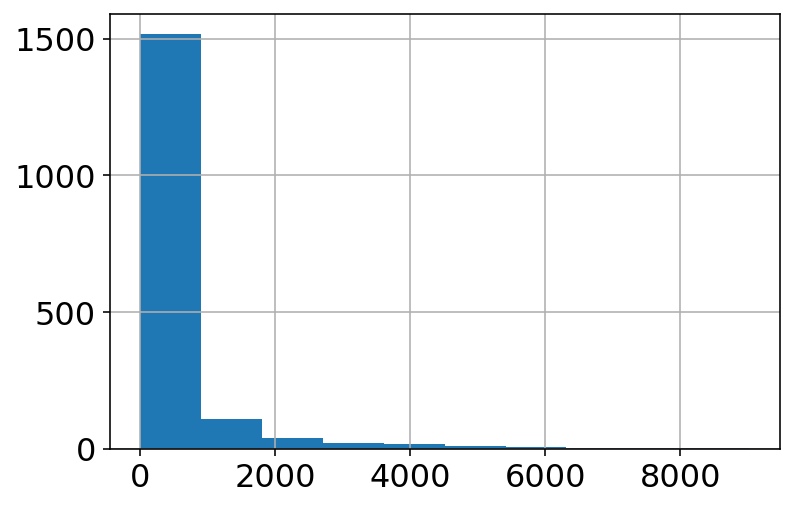

```
kepler_df['star_mass'].hist()
```

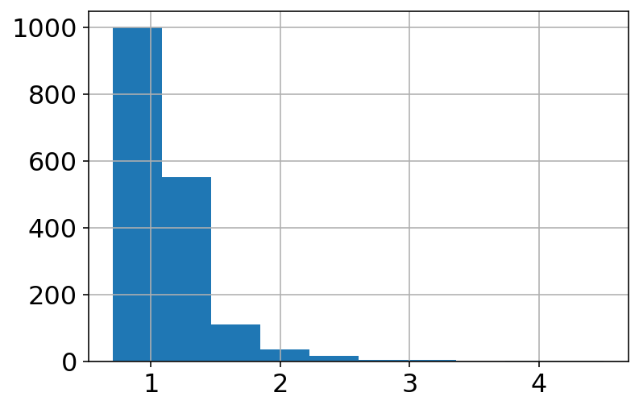

(Yes, I am aware the plots aren't pretty. These aren't supposed to be. Get in the habit of making quick and dirty plots to look at your data)

### Add another column

The process is the same as for adding the $T^2$ column.

```
kepler_df['a_3_m'] = kepler_df['semi_major_axis']**3 / kepler_df['star_mass']
```

```
kepler_df
```

|  | name | orbital_period | semi_major_axis | detection_type | star_mass | T_sq | a_3_m |
| --- | --- | --- | --- | --- | --- | --- | --- |
| 0 | 11 Com b | 326.03000 | 1.2900 | Radial Velocity | 2.70 | 1.062956e+05 | 0.795070 |
| 1 | 11 UMi b | 516.22000 | 1.5400 | Radial Velocity | 1.80 | 2.664831e+05 | 2.029036 |
| 2 | 14 And b | 185.84000 | 0.8300 | Radial Velocity | 2.20 | 3.453651e+04 | 0.259903 |
| 3 | 14 Her b | 1773.40000 | 2.7700 | Radial Velocity | 0.90 | 3.144948e+06 | 23.615481 |
| 4 | 16 Cyg B b | 799.50000 | 1.6800 | Radial Velocity | 1.01 | 6.392002e+05 | 4.694685 |
| ... | ... | ... | ... | ... | ... | ... | ... |
| 3827 | tau Gem b | 305.50000 | 1.1700 | Radial Velocity | 2.30 | 9.333025e+04 | 0.696353 |
| 3828 | ups And b | 4.61711 | 0.0590 | Radial Velocity | 1.27 | 2.131770e+01 | 0.000162 |
| 3829 | ups And c | 240.93700 | 0.8610 | Radial Velocity | 1.27 | 5.805064e+04 | 0.502581 |
| 3830 | ups And d | 1281.43900 | 2.5500 | Radial Velocity | 1.27 | 1.642086e+06 | 13.056201 |
| 3831 | ups And e | 3848.86000 | 5.2456 | Radial Velocity | 1.27 | 1.481372e+07 | 113.653232 |

1719 rows × 7 columns

```
kepler_df['orbital_period_sec'] = kepler_df['orbital_period'] * 24. * 60. * 60.
kepler_df['a_metres'] = kepler_df['semi_major_axis'] * 1.496E11
kepler_df['mass_kg'] = kepler_df['star_mass'] * 1.989E30
```

```
kepler_df['a_3_m'] = kepler_df['a_metres']**3 / kepler_df['mass_kg']
kepler_df['T_sq'] = kepler_df['orbital_period_sec']**2
```

### Estimate $G \pm \sigma_G$

We're using `curve_fit`, so we need to import it. Remember to add the import statement to the top of your notebook if you don't already have it loaded.

First things first, define the function that we want to fit. We're estimating $G$ by rearranging the equation for Kepler's 3rd law:

$$ T^2 = \dfrac{4 \pi^2}{G} \dfrac{a^3}{M_*} $$

Our function is then

```
def keplers_law(a_3_m, g):
    return (4.0 * np.pi**2  * a_3_m / g)
```

Now we use `curve_fit` to find $G$ and $\sigma_G$

**Note:** The first (few...) times I tried this it didn't work. `curve_fit` got a very strange answer. By providing a starting guess with the `p0` parameter the fit worked properly. The problem was the very large numbers ($10^6$ and $10^{17}$). As we can see from the units in the $T^2$ equation, $G$ will be approximately $\dfrac{10^6}{10^{17}} = 10^{-11}$ m$^{3}$ kg$^{-1}$ s$^{-2}$, so `p0=1e-11` is a reasonable starting guess.

```
popt, pcov = curve_fit(keplers_law, (kepler_df['a_3_m']), (kepler_df['T_sq']), p0=1e-11)
g = popt[0]
g_unc = np.sqrt(pcov[0][0])
print("G = {0:.3e} +/- {1:.3e}".format(g, g_unc))
```

```
G = 6.753e-11 +/- 1.591e-13
```

```
fig = plt.figure(figsize=(10,6))
ax = fig.add_subplot(1,1,1)
ax.plot(kepler_df['a_3_m']/1e6, kepler_df['T_sq'] / 1e17, 'k.',ls='None', label='Data')
ax.plot(kepler_df['a_3_m']/1e6, keplers_law(kepler_df['a_3_m'], g)/1e17, 'r--', label='Best fit')
ax.set_ylabel('$T^2$ ($10^{17}$ s$^2$)')
ax.set_xlabel('$a^3 / M_*$ ($10^6$ m$^3$ kg$^{-1}$)')
title_string = (r'$G = ({0:.3f} \pm {1:.3f}) \times 10^{{-11}}$ m$^{{3}}$ kg$^{{-1}}$ s$^{{-2}}$'.format((g / 1e-11), (g_unc / 1e-11)))
ax.set_title(title_string)
ax.legend()
plt.show()
```

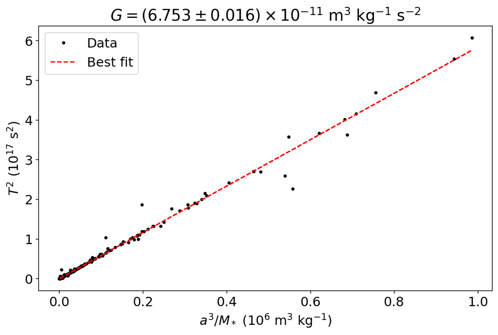